# USL Bonnus Task: Association Rules - European Social Survey

Ondřej Marvan, 477001

2026-02-04

# 1. Introduction

I analyze the European Social Survey Round 11 to find association rules with **hincfel** (Feeling about household’s income nowadays) as the consequent.

Main task: *What factors are associated with how people feel about their household income?*

**Dataset:** ESS Round 11 (2023/24) - https://ess.sikt.no/en/

# 2. Load Data

```r
ess11 <- read.csv("Data/ESS11e04_1.csv")

# Quick look
cat("Rows:", nrow(ess11), "Columns:", ncol(ess11), "\n")
cat("Countries:", length(unique(ess11$cntry)))
```

[output not shown]

**50,116 respondents** from **30 European countries** with **691 variables**, including core demographic questions (age, gender, education), attitudes (trust, political views, life satisfaction).

```r
head(ess11)
```

```
##         name essround edition   proddate  idno cntry   dweight   pspwght
## 1 ESS11e04_1       11     4.1 12.01.2026 50014    AT 1.1851145 0.3928906
## 2 ESS11e04_1       11     4.1 12.01.2026 50030    AT 0.6098981 0.3251533
## 3 ESS11e04_1       11     4.1 12.01.2026 50057    AT 1.3923296 4.0000234
## 4 ESS11e04_1       11     4.1 12.01.2026 50106    AT 0.5560615 0.1762276
## 5 ESS11e04_1       11     4.1 12.01.2026 50145    AT 0.7227953 1.0609399
## 6 ESS11e04_1       11     4.1 12.01.2026 50158    AT 0.9926053 1.3928125
##     pweight   anweight nwspol netusoft netustm ppltrst pplfair pplhlp polintr
## 1 0.3309145 0.13001321     90        5     180       5       5      5       1
## 2 0.3309145 0.10759795     90        5     570      10       0      1       2
## 3 0.3309145 1.32366590     30        5      30       6       9      8       2
## 4 0.3309145 0.05831629     15        1    6666       6       6      6       3
## 5 0.3309145 0.35108042     60        5     120       6       3      8       2
## 6 0.3309145 0.46090190    120        5     120       8       8      4       2
##   psppsgva actrolga psppipla cptppola trstprl trstlgl trstplc trstplt trstprt
```

[output cut: 552 more lines]

# 3. Inspect hincfel Variable

```r
# hincfel coding:
# 1 = Living comfortably
# 2 = Coping
# 3 = Difficult
# 4 = Very difficult

# Clean missing values (7,8,9 are refusal/don't know/no answer in ESS)
ess11 <- ess11 %>%
  filter(hincfel %in% 1:4)

cat(nrow(ess11))
```

```
## 49411
```

Variable **hincfel** has **4 categories** measuring how people feel about their household income **(1=comfortable to 4=very difficult)**. I removed invalid responses (codes 7-9) and lost ~700 cases (1.4%), leaving **49,411 valid respondents for analysis**.

```r
# Distribution
table(ess11$hincfel)
```

```
##
##     1     2     3     4
## 15585 22011  8597  3218
```

```r
prop.table(table(ess11$hincfel))
```

```
##
##         1         2         3         4
## 0.3154156 0.4454676 0.1739896 0.0651272
```

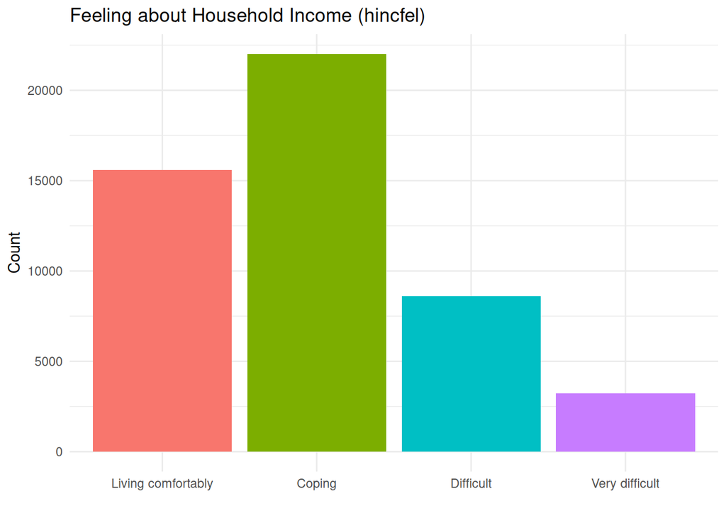

```r
# Add labels
ess11$hincfel_lab <- factor(ess11$hincfel,
                            levels = 1:4,
                            labels = c("Living comfortably", "Coping",
                                       "Difficult", "Very difficult"))

# Plot
ggplot(ess11, aes(x = hincfel_lab, fill = hincfel_lab)) +
  geom_bar() +
  labs(title = "Feeling about Household Income (hincfel)",
       x = "", y = "Count") +
  theme_minimal() +
  theme(legend.position = "none")
```

# 4. Data Preperation for Association Rules

```r
# Categorical variables for association rules
ess_data <- ess11 %>%
  mutate(
    # Target variable
    Income_Feel = case_when(
      hincfel == 1 ~ "Income=Comfortable",
      hincfel == 2 ~ "Income=Coping",
      hincfel == 3 ~ "Income=Difficult",
      hincfel == 4 ~ "Income=VeryDifficult"
    ),

    # Gender
    Gender = ifelse(gndr == 1, "Male", "Female"),

    # Age groups
    Age = case_when(
      agea < 30 ~ "Age_18-29",
      agea < 45 ~ "Age_30-44",
      agea < 60 ~ "Age_45-59",
      agea < 75 ~ "Age_60-74",
      TRUE ~ "Age_75+"
    ),

    # Education
    Edu = case_when(
      eduyrs < 12 ~ "Edu_Low",
      eduyrs < 16 ~ "Edu_Medium",
      TRUE ~ "Edu_High"
    ),

    # Health
    Health = case_when(
      health %in% 1:2 ~ "Health_Good",
      health == 3 ~ "Health_Fair",
      health %in% 4:5 ~ "Health_Poor"
    ),

    # Life satisfaction
    LifeSat = case_when(
      stflife <= 4 ~ "LifeSat_Low",
      stflife <= 7 ~ "LifeSat_Medium",
      TRUE ~ "LifeSat_High"
    ),

    # Trust
    Trust = case_when(
      ppltrst <= 4 ~ "Trust_Low",
      ppltrst <= 7 ~ "Trust_Medium",
      TRUE ~ "Trust_High"
    ),

    # Region
    Region = case_when(
      cntry %in% c("NO","SE","FI","IS","DK") ~ "Nordic",
      cntry %in% c("DE","AT","CH","NL","BE") ~ "Western",
      cntry %in% c("GB","IE") ~ "British",
      cntry %in% c("FR","ES","PT","IT","GR","CY") ~ "Southern",
      TRUE ~ "Eastern"
    )
  ) %>%
  select(Income_Feel, Gender, Age, Edu, Health, LifeSat, Trust, Region) %>%
  na.omit()

cat("Complete cases:", nrow(ess_data), "\n")
```

```
## Complete cases: 49352
```

```r
head(ess_data)
```

```
##          Income_Feel Gender       Age        Edu      Health        LifeSat
## 1 Income=Comfortable   Male Age_60-74 Edu_Medium Health_Fair   LifeSat_High
## 2      Income=Coping Female Age_18-29 Edu_Medium Health_Good   LifeSat_High
## 3 Income=Comfortable Female Age_45-59   Edu_High Health_Good   LifeSat_High
## 4      Income=Coping Female   Age_75+ Edu_Medium Health_Fair LifeSat_Medium
## 5      Income=Coping   Male Age_60-74 Edu_Medium Health_Good   LifeSat_High
## 6 Income=Comfortable Female Age_45-59   Edu_High Health_Good   LifeSat_High
##          Trust  Region
## 1 Trust_Medium Western
## 2   Trust_High Western
## 3 Trust_Medium Western
## 4 Trust_Medium Western
## 5 Trust_Medium Western
## 6   Trust_High Western
```

**8 variables**: Income_Feel (target), Gender, Age, Education, Health, Life Satisfaction, Trust, and Region. Countries are grouped into 5 regions.

```r
# Convert to transactions
trans <- as(ess_data, "transactions")
summary(trans)
```

```
## transactions as itemMatrix in sparse format with
##  49352 rows (elements/itemsets/transactions) and
##  28 columns (items) and a density of 0.2857143
##
## most frequent items:
##   Health=Health_Good        Gender=Female LifeSat=LifeSat_High
##                32383                26620                24509
##   Trust=Trust_Medium          Gender=Male              (Other)
##                22916                22732               265656
##
## element (itemset/transaction) length distribution:
## sizes
##     8
## 49352
##
##    Min. 1st Qu.  Median    Mean 3rd Qu.    Max.
##       8       8       8       8       8       8
##
## includes extended item information - examples:
##                           labels   variables             levels
## 1 Income_Feel=Income=Comfortable Income_Feel Income=Comfortable
## 2      Income_Feel=Income=Coping Income_Feel      Income=Coping
## 3   Income_Feel=Income=Difficult Income_Feel   Income=Difficult
##
## includes extended transaction information - examples:
##   transactionID
## 1             1
## 2             2
## 3             3
```

**49,352 transactions** (respondents) and **28 items** (all category levels across 8 variables). Each transaction has exactly **8 items** (one per variable) - this is expected since every person has a value for each variable.

Most frequent items show are **good health** is most common (32,383), slightly more **females** than males, and **high life satisfaction** is prevalent. This reflects the earlier finding that most Europeans feel relatively positive.

```r
# Check item labels
itemLabels(trans)
```

```
##  [1] "Income_Feel=Income=Comfortable"   "Income_Feel=Income=Coping"
##  [3] "Income_Feel=Income=Difficult"     "Income_Feel=Income=VeryDifficult"
##  [5] "Gender=Female"                    "Gender=Male"
##  [7] "Age=Age_18-29"                    "Age=Age_30-44"
##  [9] "Age=Age_45-59"                    "Age=Age_60-74"
## [11] "Age=Age_75+"                      "Edu=Edu_High"
## [13] "Edu=Edu_Low"                      "Edu=Edu_Medium"
## [15] "Health=Health_Fair"               "Health=Health_Good"
## [17] "Health=Health_Poor"               "LifeSat=LifeSat_High"
## [19] "LifeSat=LifeSat_Low"              "LifeSat=LifeSat_Medium"
## [21] "Trust=Trust_High"                 "Trust=Trust_Low"
## [23] "Trust=Trust_Medium"               "Region=British"
## [25] "Region=Eastern"                   "Region=Nordic"
## [27] "Region=Southern"                  "Region=Western"
```

This covers all categories: **4 income feelings**, **2 genders**, **5 age groups**, **3 education levels**, **3 health levels**, **3 life satisfaction levels**, **3 trust levels**, and **5 regions**.

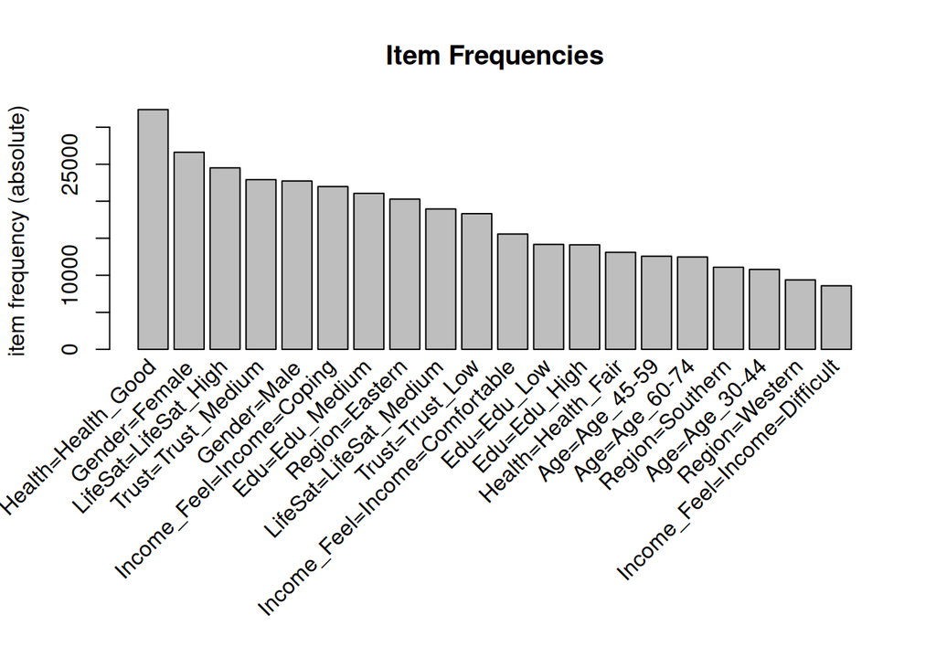

```r
itemFrequencyPlot(trans, topN = 20, type = "absolute",
                  main = "Item Frequencies")
```

This shows the **20 most frequent items** in the dataset. **“Health_Good”** is most common (~32,000), followed by **“Female”** and **“LifeSat_High”** - confirming most respondents report positive wellbeing. Further, **“Income=Coping”** appears most often (~22,000), then **“Income=Comfortable”** (~15,000), while **“Income=Difficult”** is less frequent (~8,500). **“Income=VeryDifficult”** doesn’t appear in top 20, indicating it’s rare.

# 5. Apriori Algorithm

```r
# Get income items for appearance list
income_items <- grep("Income", itemLabels(trans), value = TRUE)
income_items
```

```
## [1] "Income_Feel=Income=Comfortable"   "Income_Feel=Income=Coping"
## [3] "Income_Feel=Income=Difficult"     "Income_Feel=Income=VeryDifficult"
```

Function **grep()** to extract item labels containing “Income” from transactions. This gives the 4 target items for our association rules.

```r
# Run apriori with hincfel as consequent
rules <- apriori(trans,
                 parameter = list(supp = 0.01, conf = 0.3, minlen = 2),
                 appearance = list(rhs = income_items, default = "lhs"),
                 control = list(verbose = FALSE))

cat("Rules found:", length(rules))
```

```
## Rules found: 1826
```

for Apriori with **support ≥ 1%**, There’re **1,826 rules**.

## Top Rules by Lift

```r
inspect(head(sort(rules, by = "lift"), 15))
```

```
##      lhs                        rhs                                 support confidence   coverage     lift count
## [1]  {Gender=Male,
##       Edu=Edu_High,
##       Health=Health_Good,
##       LifeSat=LifeSat_High,
##       Region=Western}        => {Income_Feel=Income=Comfortable} 0.01442697  0.7764449 0.01858081 2.460770   712
## [2]  {Gender=Male,
##       Edu=Edu_High,
##       LifeSat=LifeSat_High,
##       Region=Western}        => {Income_Feel=Income=Comfortable} 0.01663560  0.7701689 0.02159994 2.440879   821
## [3]  {Edu=Edu_High,
##       Health=Health_Good,
##       LifeSat=LifeSat_High,
##       Region=Western}        => {Income_Feel=Income=Comfortable} 0.02463933  0.7246722 0.03400065 2.296688  1216
## [4]  {Edu=Edu_High,
##       Health=Health_Good,
##       LifeSat=LifeSat_High,
##       Trust=Trust_Medium,
##       Region=Western}        => {Income_Feel=Income=Comfortable} 0.01284649  0.7196368 0.01785135 2.280729   634
## [5]  {Gender=Male,
##       Edu=Edu_High,
##       Health=Health_Good,
##       LifeSat=LifeSat_High,
##       Trust=Trust_High}      => {Income_Feel=Income=Comfortable} 0.01369752  0.7161017 0.01912790 2.269525   676
## [6]  {Edu=Edu_High,
##       LifeSat=LifeSat_High,
##       Trust=Trust_Medium,
##       Region=Western}        => {Income_Feel=Income=Comfortable} 0.01525774  0.7137441 0.02137705 2.262054   753
## [7]  {Edu=Edu_High,
##       LifeSat=LifeSat_High,
##       Region=Western}        => {Income_Feel=Income=Comfortable} 0.02865132  0.7098394 0.04036311 2.249678  1414
## [8]  {Edu=Edu_High,
##       Trust=Trust_High,
##       Region=Western}        => {Income_Feel=Income=Comfortable} 0.01077970  0.7065073 0.01525774 2.239118   532
## [9]  {Gender=Male,
##       Edu=Edu_High,
##       Health=Health_Good,
##       Region=Western}        => {Income_Feel=Income=Comfortable} 0.01679770  0.7013536 0.02395040 2.222785   829
## [10] {Gender=Male,
##       Age=Age_60-74,
##       Edu=Edu_High,
##       LifeSat=LifeSat_High}  => {Income_Feel=Income=Comfortable} 0.01110391  0.6972010 0.01592641 2.209624   548
## [11] {Age=Age_60-74,
##       Edu=Edu_High,
##       Health=Health_Good,
##       LifeSat=LifeSat_High}  => {Income_Feel=Income=Comfortable} 0.01633166  0.6936317 0.02354515 2.198312   806
## [12] {Gender=Male,
##       Edu=Edu_High,
##       LifeSat=LifeSat_High,
##       Trust=Trust_High}      => {Income_Feel=Income=Comfortable} 0.01529827  0.6926606 0.02208624 2.195234   755
## [13] {LifeSat=LifeSat_Low,
##       Region=Southern}       => {Income_Feel=Income=Difficult}   0.01122548  0.3791923 0.02960366 2.179583   554
## [14] {Gender=Male,
##       Edu=Edu_High,
##       Region=Western}        => {Income_Feel=Income=Comfortable} 0.02026260  0.6798097 0.02980629 2.154506  1000
## [15] {Edu=Edu_High,
##       Health=Health_Good,
##       LifeSat=LifeSat_High,
##       Trust=Trust_High}      => {Income_Feel=Income=Comfortable} 0.02796239  0.6781327 0.04123440 2.149191  1380
```

Top rules by lift show the strongest associations. The **highest lift (2.46)** is for **Western European** men with **high education**, **good health**, and **high life satisfaction** → **feeling comfortable about income**. This indicates these factors strongly increase the likelihood of income comfort beyond random chance.

## Top Rules by Confidence

```r
inspect(head(sort(rules, by = "confidence"), 15))
```

```
##      lhs                        rhs                                 support confidence   coverage     lift count
## [1]  {Gender=Male,
##       Edu=Edu_High,
##       Health=Health_Good,
##       LifeSat=LifeSat_High,
##       Region=Western}        => {Income_Feel=Income=Comfortable} 0.01442697  0.7764449 0.01858081 2.460770   712
## [2]  {Gender=Male,
##       Edu=Edu_High,
##       LifeSat=LifeSat_High,
##       Region=Western}        => {Income_Feel=Income=Comfortable} 0.01663560  0.7701689 0.02159994 2.440879   821
## [3]  {Edu=Edu_High,
##       Health=Health_Good,
##       LifeSat=LifeSat_High,
##       Region=Western}        => {Income_Feel=Income=Comfortable} 0.02463933  0.7246722 0.03400065 2.296688  1216
## [4]  {Edu=Edu_High,
##       Health=Health_Good,
##       LifeSat=LifeSat_High,
##       Trust=Trust_Medium,
##       Region=Western}        => {Income_Feel=Income=Comfortable} 0.01284649  0.7196368 0.01785135 2.280729   634
## [5]  {Gender=Male,
##       Edu=Edu_High,
##       Health=Health_Good,
##       LifeSat=LifeSat_High,
##       Trust=Trust_High}      => {Income_Feel=Income=Comfortable} 0.01369752  0.7161017 0.01912790 2.269525   676
## [6]  {Edu=Edu_High,
##       LifeSat=LifeSat_High,
##       Trust=Trust_Medium,
##       Region=Western}        => {Income_Feel=Income=Comfortable} 0.01525774  0.7137441 0.02137705 2.262054   753
## [7]  {Edu=Edu_High,
##       LifeSat=LifeSat_High,
##       Region=Western}        => {Income_Feel=Income=Comfortable} 0.02865132  0.7098394 0.04036311 2.249678  1414
## [8]  {Edu=Edu_High,
##       Trust=Trust_High,
##       Region=Western}        => {Income_Feel=Income=Comfortable} 0.01077970  0.7065073 0.01525774 2.239118   532
## [9]  {Gender=Male,
##       Edu=Edu_High,
##       Health=Health_Good,
##       Region=Western}        => {Income_Feel=Income=Comfortable} 0.01679770  0.7013536 0.02395040 2.222785   829
## [10] {Gender=Male,
##       Age=Age_60-74,
##       Edu=Edu_High,
##       LifeSat=LifeSat_High}  => {Income_Feel=Income=Comfortable} 0.01110391  0.6972010 0.01592641 2.209624   548
## [11] {Age=Age_60-74,
##       Edu=Edu_High,
##       Health=Health_Good,
##       LifeSat=LifeSat_High}  => {Income_Feel=Income=Comfortable} 0.01633166  0.6936317 0.02354515 2.198312   806
## [12] {Gender=Male,
##       Edu=Edu_High,
##       LifeSat=LifeSat_High,
##       Trust=Trust_High}      => {Income_Feel=Income=Comfortable} 0.01529827  0.6926606 0.02208624 2.195234   755
## [13] {Gender=Male,
##       Edu=Edu_High,
##       Region=Western}        => {Income_Feel=Income=Comfortable} 0.02026260  0.6798097 0.02980629 2.154506  1000
## [14] {Edu=Edu_High,
##       Health=Health_Good,
##       LifeSat=LifeSat_High,
##       Trust=Trust_High}      => {Income_Feel=Income=Comfortable} 0.02796239  0.6781327 0.04123440 2.149191  1380
## [15] {Gender=Male,
##       Edu=Edu_High,
##       Trust=Trust_Medium,
##       Region=Western}        => {Income_Feel=Income=Comfortable} 0.01124574  0.6776557 0.01659507 2.147679   555
```

## Rules for Comfortable Income

```r
rules_comfort <- subset(rules, rhs %pin% "Comfortable")
cat("Rules for Comfortable:", length(rules_comfort), "\n")
```

```
## Rules for Comfortable: 587
```

```r
inspect(head(sort(rules_comfort, by = "lift"), 10))
```

```
##      lhs                        rhs                                 support confidence   coverage     lift count
## [1]  {Gender=Male,
##       Edu=Edu_High,
##       Health=Health_Good,
##       LifeSat=LifeSat_High,
##       Region=Western}        => {Income_Feel=Income=Comfortable} 0.01442697  0.7764449 0.01858081 2.460770   712
## [2]  {Gender=Male,
##       Edu=Edu_High,
##       LifeSat=LifeSat_High,
##       Region=Western}        => {Income_Feel=Income=Comfortable} 0.01663560  0.7701689 0.02159994 2.440879   821
## [3]  {Edu=Edu_High,
##       Health=Health_Good,
##       LifeSat=LifeSat_High,
##       Region=Western}        => {Income_Feel=Income=Comfortable} 0.02463933  0.7246722 0.03400065 2.296688  1216
## [4]  {Edu=Edu_High,
##       Health=Health_Good,
##       LifeSat=LifeSat_High,
##       Trust=Trust_Medium,
##       Region=Western}        => {Income_Feel=Income=Comfortable} 0.01284649  0.7196368 0.01785135 2.280729   634
## [5]  {Gender=Male,
##       Edu=Edu_High,
##       Health=Health_Good,
##       LifeSat=LifeSat_High,
##       Trust=Trust_High}      => {Income_Feel=Income=Comfortable} 0.01369752  0.7161017 0.01912790 2.269525   676
## [6]  {Edu=Edu_High,
##       LifeSat=LifeSat_High,
##       Trust=Trust_Medium,
##       Region=Western}        => {Income_Feel=Income=Comfortable} 0.01525774  0.7137441 0.02137705 2.262054   753
## [7]  {Edu=Edu_High,
##       LifeSat=LifeSat_High,
##       Region=Western}        => {Income_Feel=Income=Comfortable} 0.02865132  0.7098394 0.04036311 2.249678  1414
## [8]  {Edu=Edu_High,
##       Trust=Trust_High,
##       Region=Western}        => {Income_Feel=Income=Comfortable} 0.01077970  0.7065073 0.01525774 2.239118   532
## [9]  {Gender=Male,
##       Edu=Edu_High,
##       Health=Health_Good,
##       Region=Western}        => {Income_Feel=Income=Comfortable} 0.01679770  0.7013536 0.02395040 2.222785   829
## [10] {Gender=Male,
##       Age=Age_60-74,
##       Edu=Edu_High,
##       LifeSat=LifeSat_High}  => {Income_Feel=Income=Comfortable} 0.01110391  0.6972010 0.01592641 2.209624   548
```

**Best rule:** Western European men with high education, good health, and high life satisfaction have 77.6% probability of feeling comfortable.

## Rules for Difficult Income

```r
rules_diff <- subset(rules, rhs %pin% "Difficult")
cat("Rules for Difficult/VeryDifficult:", length(rules_diff), "\n")
```

```
## Rules for Difficult/VeryDifficult: 38
```

```r
inspect(head(sort(rules_diff, by = "lift"), 10))
```

```
##      lhs                       rhs                               support confidence   coverage     lift count
## [1]  {LifeSat=LifeSat_Low,
##       Region=Southern}      => {Income_Feel=Income=Difficult} 0.01122548  0.3791923 0.02960366 2.179583   554
## [2]  {Health=Health_Fair,
##       LifeSat=LifeSat_Low}  => {Income_Feel=Income=Difficult} 0.01497406  0.3624326 0.04131545 2.083249   739
## [3]  {Gender=Female,
##       LifeSat=LifeSat_Low,
##       Trust=Trust_Low}      => {Income_Feel=Income=Difficult} 0.01412303  0.3603930 0.03918787 2.071525   697
## [4]  {Age=Age_60-74,
##       LifeSat=LifeSat_Low}  => {Income_Feel=Income=Difficult} 0.01199546  0.3570567 0.03359540 2.052348   592
## [5]  {Edu=Edu_Medium,
##       LifeSat=LifeSat_Low,
##       Region=Eastern}       => {Income_Feel=Income=Difficult} 0.01094181  0.3483871 0.03140704 2.002516   540
## [6]  {Gender=Female,
##       LifeSat=LifeSat_Low,
##       Region=Eastern}       => {Income_Feel=Income=Difficult} 0.01365699  0.3463515 0.03943103 1.990815   674
## [7]  {Edu=Edu_Medium,
##       LifeSat=LifeSat_Low}  => {Income_Feel=Income=Difficult} 0.01801345  0.3453768 0.05215594 1.985213   889
## [8]  {Edu=Edu_Medium,
##       LifeSat=LifeSat_Low,
##       Trust=Trust_Low}      => {Income_Feel=Income=Difficult} 0.01029340  0.3444068 0.02988734 1.979637   508
## [9]  {Gender=Female,
##       LifeSat=LifeSat_Low}  => {Income_Feel=Income=Difficult} 0.02285622  0.3442173 0.06640055 1.978548  1128
## [10] {Age=Age_45-59,
##       LifeSat=LifeSat_Low}  => {Income_Feel=Income=Difficult} 0.01104312  0.3425519 0.03223780 1.968975   545
```

**Only 38 rules for “Difficult”** - fewer because this outcome is less common. The top rule shows people with **low life satisfaction** in **Southern Europe** have a 38% chance of **finding income difficult** (**lift 2.18**). Low life satisfaction appears in all top rules, making it the dominant predictor of financial difficulty.

# 6. ECLAT

```r
itemsets <- eclat(trans, parameter = list(supp = 0.02, minlen = 2),
                  control = list(verbose = FALSE))
cat("Itemsets:", length(itemsets))
```

```
## Itemsets: 2266
```

**2,266 itemsets** with at least 2% support and minimum 2 items.

```r
# Itemsets with income
income_sets <- subset(itemsets, items %pin% "Income")
inspect(head(sort(income_sets, by = "support"), 10))
```

```
##      items                               support count
## [1]  {Income_Feel=Income=Coping,
##       Health=Health_Good}              0.2928757 14454
## [2]  {Income_Feel=Income=Comfortable,
##       Health=Health_Good}              0.2458462 12133
## [3]  {Income_Feel=Income=Coping,
##       Gender=Female}                   0.2414087 11914
## [4]  {Income_Feel=Income=Comfortable,
##       LifeSat=LifeSat_High}            0.2225442 10983
## [5]  {Income_Feel=Income=Coping,
##       LifeSat=LifeSat_High}            0.2140744 10565
## [6]  {Income_Feel=Income=Coping,
##       Trust=Trust_Medium}              0.2101435 10371
## [7]  {Income_Feel=Income=Coping,
##       Edu=Edu_Medium}                  0.2046726 10101
## [8]  {Income_Feel=Income=Coping,
##       Gender=Male}                     0.2040444 10070
## [9]  {Income_Feel=Income=Coping,
##       Region=Eastern}                  0.1970336  9724
## [10] {Income_Feel=Income=Coping,
##       LifeSat=LifeSat_Medium}          0.1886043  9308
```

Top itemset: **“Coping” + “Good Health”** appears in 29% of respondents (14,454 people) - simply because both are the most common categories in their own variables. **“Coping”** dominates (8 of top 10) because it’s the most frequent income category. **“Comfortable”** pairs with **good health** and **high life satisfaction**.

# 7. Visualizations

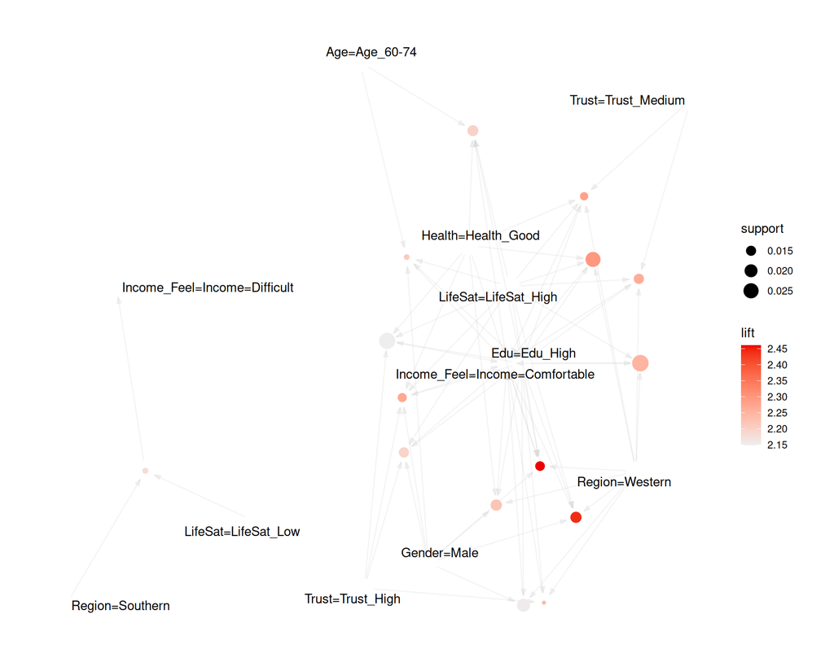

```r
top15 <- head(sort(rules, by = "lift"), 15)
plot(top15, method = "graph")
```

Network shows two separate clusters - **“Comfortable”** (right) connects to **high education**, **Western region**, **good health**; **“Difficult”** (left) connects to **low life satisfaction** and **Southern region**. The clusters don’t overlap, meaning different factors predict each outcome.

[output not shown]

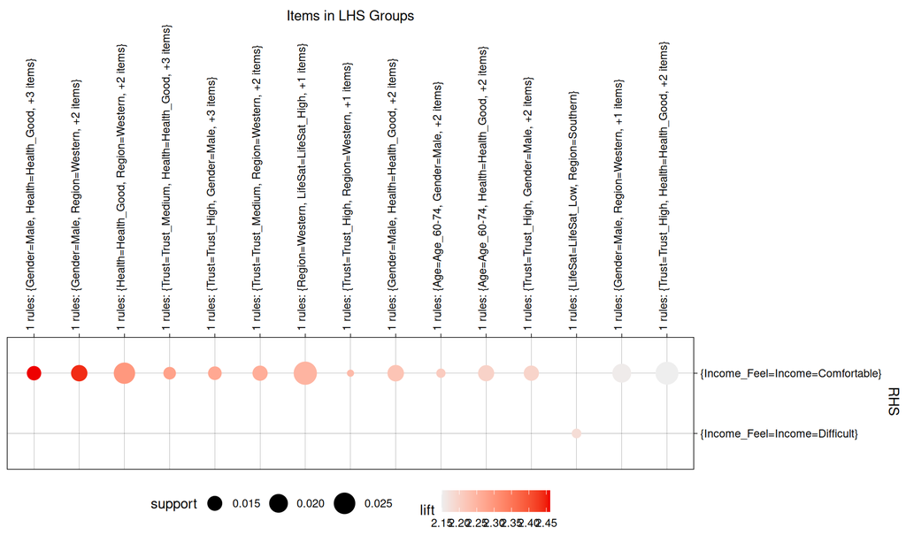

```r
plot(top15, method = "grouped", main = "Grouped Matrix")
```

Rules organized by consequent (RHS). Top row: 14 rules predict **“Comfortable”** (red = high lift ~2.4). Bottom row: only 1 rule predicts **“Difficult”** (lighter = lower lift ~2.18). Most rules combine **Western region**, **high education**, **good health**, and **male gender** to predict income comfort. The single **“Difficult”** rule involves **low life satisfaction** + **Southern region**.

# 8. Conclusion

**Interpretation:**

High lift values (around 2.0-2.5) indicate these associations are about twice as strong as random chance. High confidence (70-78% for comfortable rules) means the rules are reliable predictors. However, these are associations and not causal relationships.

**Reference:** European Social Survey Round 11 (ESS ERIC, 2024). https://ess.sikt.no/en/